# Algrebra Lineal Basica con R

Created By Julio SOLANO

April 24, 2017

## 1. Vectores

- Muchas operaciones realizadas sobre datos multivariables son facilitados usando la notación de vector y matriz.
- Utilizaremos letras minusculas pra denotar vectores.

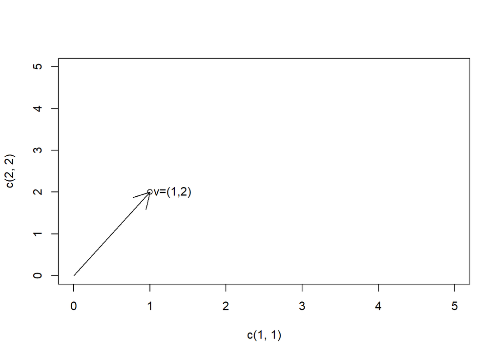

```r
# draw the vector

plot(c(1,1),c(2,2), xlim=c(0,5), ylim=c(0,5))
arrows(0, 0, 1, 2)
text(1.3, 2, "v=(1,2)")
```

```r
x <- seq(2,8,2)
x
```

```
## [1] 2 4 6 8
```

```r
y <- 4:1
y
```

```
## [1] 4 3 2 1
```

```r
x+y # Suma de vectores
```

```
## [1] 6 7 8 9
```

```r
crossprod(x,y) # crossprod retorna matriz 1x1, no un escalar.
```

```
##      [,1]
## [1,]   40
```

```r
crossprod(x)
```

```
##      [,1]
## [1,]  120
```

```r
x*y   # Multiplicación de vectores elemento por elemento
```

```
## [1]  8 12 12  8
```

```r
x
```

```
## [1] 2 4 6 8
```

```r
x %o% x # Producto xx’, es uma matriz nxn
```

```
##      [,1] [,2] [,3] [,4]
## [1,]    4    8   12   16
## [2,]    8   16   24   32
## [3,]   12   24   36   48
## [4,]   16   32   48   64
```

```r
(x %o% x)[, 3] # Fila 3 del producto xx’. Tratado como vector
```

```
## [1] 12 24 36 48
```

```r
(x %o% x)[2,] # Fila 2 del producto xx’. Tratado como vector
```

```
## [1]  8 16 24 32
```

```r
diag(1, 4, 4) # Matriz identidad 4x4
```

```
##      [,1] [,2] [,3] [,4]
## [1,]    1    0    0    0
## [2,]    0    1    0    0
## [3,]    0    0    1    0
## [4,]    0    0    0    1
```

```r
matrix(1, 4, 4) # Matriz 4x4 com todos sus elementos = 1
```

```
##      [,1] [,2] [,3] [,4]
## [1,]    1    1    1    1
## [2,]    1    1    1    1
## [3,]    1    1    1    1
## [4,]    1    1    1    1
```

## 2. Matrices

- Para crear una matriz en R se utiliza la función: **matrix(data = NA, nrow = 1, ncol = 1, byrow = FALSE, dimnames = NULL)**

donde matrix() corresponde al nombre de la función y todo lo que esta dentro de los parentesis son los argumentos de dicha funcion.  
- **data** es un vector de datos opcional  
- **nrow** número deseado de filas  
- **ncol** número deseado de columnas  
- **byrow** valor lógico. Si es falso (valor por defecto), la matriz se llena por orden columna, de otra manera se llenara primero por filas  
- **dimnames** utilizado para darles nombres a las filas y a las columnas, respectivamente

- Utilizaremos letras mayúsculas para denotar matrices.
- Para obtener más informacion sobre las matrices escriba **?matrix** y ejecutelo pulsando enter si trabaja directamente en la pagina principal de R o pulsando Ctrl + r si trabaja desde un script.

```r
M1 <- matrix(data = c(5, 7, 13, 4, 1, 7, 14, 3, 11), nrow=3, ncol=3, byrow=F, dimnames=list(c("Blanco", "Negro", "Rojo"), c("Toyota", "Audi", "Nissan")))
M1
```

```
##        Toyota Audi Nissan
## Blanco      5    4     14
## Negro       7    1      3
## Rojo       13    7     11
```

```r
Azul<-c(8,5,7) # Agregando filas: con esto creamos el vector Azul con sus correspondientes elementos
M2 <- rbind(M1, Azul)

Hyundai<-c(2,7,3,5) # Agregando columnas: con esto creamos el vector Hyundai con sus correspondientes elementos
M3 <- cbind(M1, Hyundai)
matrix(1:16, 4, 4) # Matriz 4x4 del 1 al 16
```

```
##      [,1] [,2] [,3] [,4]
## [1,]    1    5    9   13
## [2,]    2    6   10   14
## [3,]    3    7   11   15
## [4,]    4    8   12   16
```

```r
# Otra manera de crear matrices es a traves de vectores, los cuales seran nuestras columnas
a <- c(1,2,3,4,5,6)
b <- c(2,3,5,6,1,9)
c <- c(3,5,5,5,10,8)
d <- c(10,20,30,40,50,55)
e <- c(7,8,9,4,6,10)

# Crear una matriz a partir de los vectores anteriores
M4 <- cbind(a,b,c,d,e)
M4
```

```
##      a b  c  d  e
## [1,] 1 2  3 10  7
## [2,] 2 3  5 20  8
## [3,] 3 5  5 30  9
## [4,] 4 6  5 40  4
## [5,] 5 1 10 50  6
## [6,] 6 9  8 55 10
```

```r
# Más formas de crear matrices...
M5 <- matrix(c( 5, -1, -2,
               4,  4, -1,
              -2,  5, -3,
              -7, -8,  6),
            byrow = T, nrow = 4, ncol = 3,
            dimnames = list(c("P1", "P2", "P3", "P4"), c("V1", "V2", "V3")))
M5
```

```
##    V1 V2 V3
## P1  5 -1 -2
## P2  4  4 -1
## P3 -2  5 -3
## P4 -7 -8  6
```

```r
M6 <- matrix(sample(c(0:100), 100, replace = FALSE), 10, 10) # Matriz 10x10 del 1 al 100
M6
```

```
##       [,1] [,2] [,3] [,4] [,5] [,6] [,7] [,8] [,9] [,10]
##  [1,]   16   59   80   36   60   12   26   48   74    79
##  [2,]   57   73   88   46    1   61   55   98   68    81
##  [3,]   39   67  100   95   69   15   99   17   24    40
##  [4,]   90   43   89   66    0   11   64   58   63    22
##  [5,]    4   49   19   75   32   72   93   82   54    45
##  [6,]   97   25   47   83    6   13   30   86    3    34
##  [7,]   84   92   87   94   56   70   62   77   18    53
##  [8,]   35   42    7   21   71   33   50   65    2    96
##  [9,]   28   10   31   44   14   38   27   91   29     5
## [10,]   20   76    9   41   37   52   78   51   23     8
```

```r
# Dimensión de una matriz (mxn)
dim(M4)
```

```
## [1] 6 5
```

```r
t(matrix(1:16, 4, 4)) # Transpuesta de una matriz
```

```
##      [,1] [,2] [,3] [,4]
## [1,]    1    2    3    4
## [2,]    5    6    7    8
## [3,]    9   10   11   12
## [4,]   13   14   15   16
```

```r
diag(t(matrix(1:16, 4, 4))) # Extrae la diagonal
```

```
## [1]  1  6 11 16
```

```r
A <- matrix(data= c(1,2,3,2,4,6,3,6,9,4,8,12), nrow=3, ncol=4, byrow=F)
A
```

```
##      [,1] [,2] [,3] [,4]
## [1,]    1    2    3    4
## [2,]    2    4    6    8
## [3,]    3    6    9   12
```

```r
B <- matrix(data= c(2,4,6,4,8,12,6,12,18,8,16,24), nrow=3, ncol=4, byrow=F)
B
```

```
##      [,1] [,2] [,3] [,4]
## [1,]    2    4    6    8
## [2,]    4    8   12   16
## [3,]    6   12   18   24
```

```r
t(B) # Transpuesta de B (B'), se convierte en una matriz 4x3
```

```
##      [,1] [,2] [,3]
## [1,]    2    4    6
## [2,]    4    8   12
## [3,]    6   12   18
## [4,]    8   16   24
```

```r
# data freme to matrix
my.matrix <- as.matrix(M5)
class(M5)
```

```
## [1] "matrix"
```

### 2.1. Suma de Matrices

Dos matrices son conformables para la suma y resta si son de la misma dimension, teniendo esto en mente, en R podemos facilmente sumar y restar matrices indicando la suma con + y la resta con –

```r
A+B # Suma matricial
```

```
##      [,1] [,2] [,3] [,4]
## [1,]    3    6    9   12
## [2,]    6   12   18   24
## [3,]    9   18   27   36
```